# Assignment 9 - K-means

Author

Aytan Pirverdiyeva

# 1 Goal of this assignment

The goal of this assignment is for you to **explore the k-means algorithm** learned in class.

In specific, you will be asked to:  
- Use a different number of k than what we did in class,  
- Validate the results of the new model, and  
- Compare your results with those found in class

# 2 Instructions

You will first need to watch (and code along with) the following k-means video:

- k-means lab: https://youtu.be/GFgMp5tYiMU?si=CI0E-2r-cYZLGVL1 (start from beginning of video, watch till the 01:10)
- The partial script for the video above is in our GitHub repository, 04-classcode, **03-25_multivar_kmeans_partial.qmd**. Move the script mentioned above into the `code` subfolder of your `10_multivar` project

**AFTER watching the video and developing the code in class**, then start working on this HW assignment (instructions below):

- Move this script into the `code` subfolder of your `10_multivar` project
- On this script, fill your name under the `title` section of the YAML
- Go back to the class k-means script, choose a different number of k than what we did in class, and run it.

# 3 Setup

```r
#install.packages("ggcorrplot")
#install.packages("factoextra")
#install.packages("ggpmisc")

library(tidyverse)
library(ggcorrplot)
library(broom)
library(car)
library(factoextra)
library(ggpmisc)
```

```r
weather <- read_csv("../../09_opendata/data/weather_monthsum.csv")
weather
```

```
# A tibble: 698 × 75
    year site    strength_gtex mean_dayl.s_Jan mean_srad.wm2_Jan mean_tmax.c_Jan
   <dbl> <chr>           <dbl>           <dbl>             <dbl>           <dbl>
 1  1980 Altus,…          25.3          35873.              242.            10.2
 2  1980 Ames P…          27.2          35743.              215.             9.2
 3  1980 Artesi…          26            36359               279.            13.4
 4  1980 Auburn…          24.8          36420.              240.            13.9
 5  1980 Beevil…          24.5          37494.              277             19.9
 6  1980 Belle …          28.1          35873.              224.             9.7
 7  1980 Bossie…          25.9          36451.              221.            13.2
 8  1980 Chicka…          25.9          35760.              244              9.5
 9  1980 Clarkd…          26.1          35678.              265.             5.8
10  1980 Colleg…          27.1          36941.              254             15.8
# ℹ 688 more rows
# ℹ 69 more variables: mean_tmin.c_Jan <dbl>, mean_vp.pa_Jan <dbl>,
#   sum_prcp.mm_Jan <dbl>, mean_dayl.s_Feb <dbl>, mean_srad.wm2_Feb <dbl>,
#   mean_tmax.c_Feb <dbl>, mean_tmin.c_Feb <dbl>, mean_vp.pa_Feb <dbl>,
#   sum_prcp.mm_Feb <dbl>, mean_dayl.s_Mar <dbl>, mean_srad.wm2_Mar <dbl>,
#   mean_tmax.c_Mar <dbl>, mean_tmin.c_Mar <dbl>, mean_vp.pa_Mar <dbl>,
#   sum_prcp.mm_Mar <dbl>, mean_dayl.s_Apr <dbl>, mean_srad.wm2_Apr <dbl>, …
```

```r
weather_n <- weather %>%
  dplyr::select(-c(year:strength_gtex))

weather_n
```

```
# A tibble: 698 × 72
   mean_dayl.s_Jan mean_srad.wm2_Jan mean_tmax.c_Jan mean_tmin.c_Jan
             <dbl>             <dbl>           <dbl>           <dbl>
 1          35873.              242.            10.2            -1.5
 2          35743.              215.             9.2             0.2
 3          36359               279.            13.4            -2.4
 4          36420.              240.            13.9             2.9
 5          37494.              277             19.9             7.2
 6          35873.              224.             9.7             0.7
 7          36451.              221.            13.2             3.2
 8          35760.              244              9.5            -1.8
 9          35678.              265.             5.8            -5.8
10          36941.              254             15.8             5.6
# ℹ 688 more rows
# ℹ 68 more variables: mean_vp.pa_Jan <dbl>, sum_prcp.mm_Jan <dbl>,
#   mean_dayl.s_Feb <dbl>, mean_srad.wm2_Feb <dbl>, mean_tmax.c_Feb <dbl>,
#   mean_tmin.c_Feb <dbl>, mean_vp.pa_Feb <dbl>, sum_prcp.mm_Feb <dbl>,
#   mean_dayl.s_Mar <dbl>, mean_srad.wm2_Mar <dbl>, mean_tmax.c_Mar <dbl>,
#   mean_tmin.c_Mar <dbl>, mean_vp.pa_Mar <dbl>, sum_prcp.mm_Mar <dbl>,
#   mean_dayl.s_Apr <dbl>, mean_srad.wm2_Apr <dbl>, mean_tmax.c_Apr <dbl>, …
```

```r
# normalizing the data
weather_norm <- weather_n%>%
  mutate(across(everything(), ~ scale(.x)))

weather_norm
```

```
# A tibble: 698 × 72
   mean_dayl.s_Jan[,1] mean_srad.wm2_Jan[,1] mean_tmax.c_Jan[,1]
                 <dbl>                 <dbl>               <dbl>
 1             -0.699                 -0.962            -0.904
 2             -0.905                 -1.96             -1.15
 3              0.0762                 0.365            -0.116
 4              0.174                 -1.07              0.00684
 5              1.89                   0.285             1.48
 6             -0.699                 -1.64             -1.03
 7              0.222                 -1.73             -0.166
 8             -0.879                 -0.905            -1.08
 9             -1.01                  -0.151            -1.99
10              1.00                  -0.544             0.475
# ℹ 688 more rows
# ℹ 69 more variables: mean_tmin.c_Jan <dbl[,1]>, mean_vp.pa_Jan <dbl[,1]>,
#   sum_prcp.mm_Jan <dbl[,1]>, mean_dayl.s_Feb <dbl[,1]>,
#   mean_srad.wm2_Feb <dbl[,1]>, mean_tmax.c_Feb <dbl[,1]>,
#   mean_tmin.c_Feb <dbl[,1]>, mean_vp.pa_Feb <dbl[,1]>,
#   sum_prcp.mm_Feb <dbl[,1]>, mean_dayl.s_Mar <dbl[,1]>,
#   mean_srad.wm2_Mar <dbl[,1]>, mean_tmax.c_Mar <dbl[,1]>, …
```

```r
summary(weather_norm)
```

```
  mean_dayl.s_Jan.V1  mean_srad.wm2_Jan.V1  mean_tmax.c_Jan.V1
 Min.   :-1.7840734   Min.   :-2.5126540   Min.   :-3.0712033
 1st Qu.:-0.6992058   1st Qu.:-0.7819588   1st Qu.:-0.6580142
 Median : 0.0762234   Median :-0.0662441   Median :-0.0177804
 Mean   : 0.0000000   Mean   : 0.0000000   Mean   : 0.0000000
 3rd Qu.: 0.4629815   3rd Qu.: 0.7747656   3rd Qu.: 0.5978291
 Max.   : 2.7278918   Max.   : 2.5243904   Max.   : 2.7893988
  mean_tmin.c_Jan.V1   mean_vp.pa_Jan.V1  sum_prcp.mm_Jan.V1
 Min.   :-2.8440574   Min.   :-2.000127   Min.   :-1.056451
 1st Qu.:-0.7440901   1st Qu.:-0.647772   1st Qu.:-0.789259
 Median :-0.0611220   Median :-0.033045   Median :-0.309824
 Mean   : 0.0000000   Mean   : 0.000000   Mean   : 0.000000
 3rd Qu.: 0.6537605   3rd Qu.: 0.617939   3rd Qu.: 0.542087
 Max.   : 3.0026601   Max.   : 3.471513   Max.   : 5.347766
  mean_dayl.s_Feb.V1  mean_srad.wm2_Feb.V1  mean_tmax.c_Feb.V1
 Min.   :-1.6883608   Min.   :-2.4675108   Min.   :-3.0763659
 1st Qu.:-0.7421130   1st Qu.:-0.7391528   1st Qu.:-0.6473441
 Median : 0.0337997   Median :-0.0318076   Median : 0.0621227
 Mean   : 0.0000000   Mean   : 0.0000000   Mean   : 0.0000000
 3rd Qu.: 0.4217561   3rd Qu.: 0.7704167   3rd Qu.: 0.6513409
 Max.   : 2.8140229   Max.   : 2.6333049   Max.   : 2.6715174
  mean_tmin.c_Feb.V1   mean_vp.pa_Feb.V1  sum_prcp.mm_Feb.V1
 Min.   :-2.9175730   Min.   :-1.996629   Min.   :-1.021141
 1st Qu.:-0.6783760   1st Qu.:-0.700365   1st Qu.:-0.784401
 Median :-0.0146805   Median : 0.034733   Median :-0.263271
 Mean   : 0.0000000   Mean   : 0.000000   Mean   : 0.000000
 3rd Qu.: 0.6304068   3rd Qu.: 0.659984   3rd Qu.: 0.437873
 Max.   : 3.1363226   Max.   : 3.943916   Max.   : 4.680282
  mean_dayl.s_Mar.V1  mean_srad.wm2_Mar.V1 mean_tmax.c_Mar.V1
 Min.   :-1.7148502   Min.   :-2.1399102   Min.   :-3.809472
 1st Qu.:-0.6839818   1st Qu.:-0.7268655   1st Qu.:-0.613409
 Median :-0.2131353   Median :-0.1594528   Median : 0.056847
 Mean   : 0.0000000   Mean   : 0.0000000   Mean   : 0.000000
 3rd Qu.: 0.7452037   3rd Qu.: 0.6739143   3rd Qu.: 0.642439
 Max.   : 2.8961160   Max.   : 2.8770763   Max.   : 2.596765
 mean_tmin.c_Mar.V1   mean_vp.pa_Mar.V1  sum_prcp.mm_Mar.V1
 Min.   :-3.592408   Min.   :-1.946199   Min.   :-1.070326
 1st Qu.:-0.637721   1st Qu.:-0.822989   1st Qu.:-0.836354
 Median :-0.057336   Median : 0.118497   Median :-0.237556
 Mean   : 0.000000   Mean   : 0.000000   Mean   : 0.000000
```

[output cut: 113 more lines]

```
 Max.   : 3.411104   Max.   : 3.884142   Max.   : 4.738017
  mean_dayl.s_Dec.V1  mean_srad.wm2_Dec.V1 mean_tmax.c_Dec.V1
 Min.   :-1.8013840   Min.   :-2.6423723   Min.   :-3.277695
 1st Qu.:-0.6937959   1st Qu.:-0.7628055   1st Qu.:-0.571502
 Median : 0.0641988   Median :-0.0256720   Median :-0.009839
 Mean   : 0.0000000   Mean   : 0.0000000   Mean   : 0.000000
 3rd Qu.: 0.4683589   3rd Qu.: 0.7502581   3rd Qu.: 0.577354
 Max.   : 2.7280650   Max.   : 2.6207449   Max.   : 2.824005
 mean_tmin.c_Dec.V1   mean_vp.pa_Dec.V1  sum_prcp.mm_Dec.V1
 Min.   :-3.305944   Min.   :-2.201135   Min.   :-1.041309
 1st Qu.:-0.655678   1st Qu.:-0.622579   1st Qu.:-0.820502
 Median :-0.024662   Median :-0.065989   Median :-0.323777
 Mean   : 0.000000   Mean   : 0.000000   Mean   : 0.000000
 3rd Qu.: 0.606354   3rd Qu.: 0.534793   3rd Qu.: 0.593851
 Max.   : 3.433305   Max.   : 4.425361   Max.   : 4.025802
```

```r
mod_km4 <- kmeans(weather_norm,
                 centers = 4,
                 nstart = 10
                 )

mod_km4
```

```
K-means clustering with 4 clusters of sizes 16, 107, 336, 239

Cluster means:
  mean_dayl.s_Jan mean_srad.wm2_Jan mean_tmax.c_Jan mean_tmin.c_Jan
1      -1.0092819         1.0677218      -1.5444919      -2.0781119
2       1.7254990         0.6955010       1.1144808       1.3299878
3      -0.4147868        -0.6464799      -0.5285896      -0.2177305
4      -0.1218055         0.5260046       0.3475671      -0.1502153
  mean_vp.pa_Jan sum_prcp.mm_Jan mean_dayl.s_Feb mean_srad.wm2_Feb
1    -1.24949113      -0.1334433      -1.0010935         1.2373778
2     1.32417980      -0.1385924       1.7172512         0.2876501
3     0.07216392       0.5346413      -0.4153366        -0.5730300
4    -0.61063790      -0.6806486      -0.1178882         0.5939811
  mean_tmax.c_Feb mean_tmin.c_Feb mean_vp.pa_Feb sum_prcp.mm_Feb
1      -1.8783891      -2.2492254     -1.2679678     -0.05886532
```

[output cut: 108 more lines]

# 4 Questions

## 4.1 1. What number of k did you select? Why?

## 4.2 For this experiment, I chose k=5 in order to test if an extra cluster will highlight any more nuanced patterns in the data that would have been clustered together in the 4-cluster model.

```r
mod_km5 <- kmeans(weather_norm,
                 centers = 5,
                 nstart = 10
                 )

mod_km5
```

```
K-means clustering with 5 clusters of sizes 56, 208, 182, 16, 236

Cluster means:
  mean_dayl.s_Jan mean_srad.wm2_Jan mean_tmax.c_Jan mean_tmin.c_Jan
1       2.3860907         1.1248966       1.6039109       1.8788174
2       0.3464838        -0.2945247       0.1045128       0.3448046
3      -0.8935712        -0.8039094      -0.9466065      -0.6076648
4      -1.0092819         1.0677218      -1.5444919      -2.0781119
5      -0.1140307         0.5402326       0.3620194      -0.1402048
  mean_vp.pa_Jan sum_prcp.mm_Jan mean_dayl.s_Feb mean_srad.wm2_Feb
1      1.7014733      -0.4553440       2.3818873         0.6285026
2      0.5538344       0.6249771       0.3439249        -0.3606030
3     -0.2554043       0.3226295      -0.8933065        -0.6550968
4     -1.2494911      -0.1334433      -1.0010935         1.2373778
5     -0.6101891      -0.6825400      -0.1115373         0.5899952
```

[output cut: 126 more lines]

## 4.3 2. How many observations are there in each cluster?

```r
weather%>%
  mutate(cluster = mod_km5$cluster) %>%
  group_by(cluster) %>%
  tally()
```

```
# A tibble: 5 × 2
  cluster     n
    <int> <int>
1       1    56
2       2   208
3       3   182
4       4    16
5       5   236
```

## 4.4 3. Using the `fviz_cluster()` function, import here the original plot with k=4 did in class, and the new one with the number of k you selected for this exercise. How do they visually compare? Which one seems to be a better choice, and why?

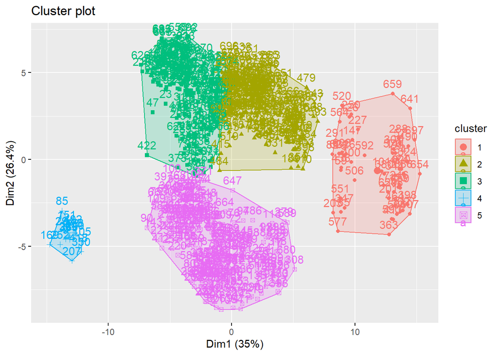

```r
fviz_cluster(mod_km5,
             data = weather_norm)
```

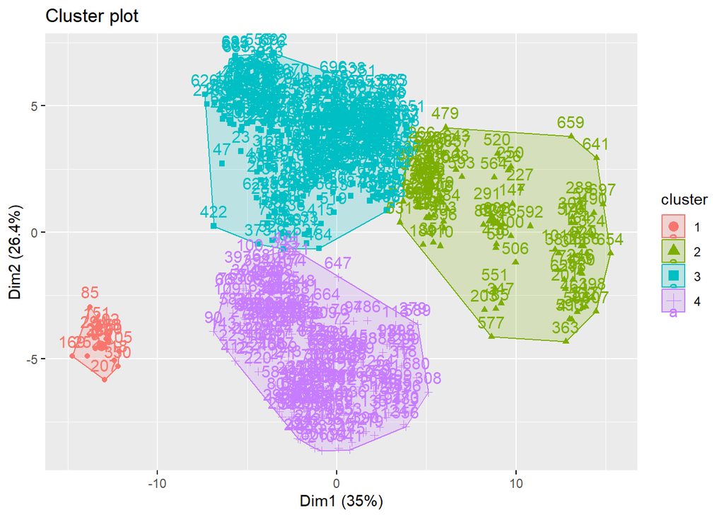

```r
fviz_cluster(mod_km4,
             data = weather_norm)
```

# 5 Submitting your work

Once you have developed all the code and answers, make sure to Render this quarto file.

**Notes on rendering**:

- Make sure to render your work and inspect how the final html look like.
- If it does not look professional for whatever reason, then fix the issue, re-render it, recheck.
- Only send me your work once your html file looks professional.
  - **DO NOT** delete the file’s heading levels (# and ##). They set up the proper heading 1 and 2 levels, and I use them to guide my grading.
  - If a given chunk is also outputting warnings or messages, inhibit this behavior by changing the chunk options `message` and `warning` to `FALSE` (I’ll demo this in a moment).
  - If, after rendered, 2 lines of text are connected and you wish to “break line” between them, add 2 extra spaces after the first one (I’lld demo this in a moment).

After rendering, an .html file will be created on your `code` folder.

Rename this file to `Assignment-09-kmeans-LASTNAME.html`.

For ex., mine would be `Assignment-09-kmeans-Bastos.html`.

Submit your work by uploading the **html** file to **eLC Assignment #9 - K-means** by April 3rd 11:59 pm.